# Analysis of the visual assisstants in the eligible papers

Carlos Granell

08 agosto, 2020

This document is an exploratory analysis of the virtual assisstants included in the eligible papers. It’s part of a collaborative scoping review activity as part of the [IDEAIS project](https://sites.google.com/view/redideais).

## Required libraries

```r
library(here)
library(tidyverse)
library(kableExtra)
library(DT)
# library(ggrepel)
library(stringr)
library(grid)
library(gridExtra)


library(ggforce) # for parallel sets diagram
library(gghighlight)

# just in case
set.seed(nchar("IDEAIS - scoping review paper"))
```

## Data

```
## Using ',' as decimal and '.' as grouping mark. Use read_delim() for more control.
```

| ID | Year | [AV] Application | [AV] Name | [AV] Place | [AV] Dev. status | [AV] Arch. | [AV] Platform | [Geo] Goal | [Geo] Sources | [Geo] Tech | [Geo] Input | [Geo] Output | [Geo] Standards? | [Geo] Process? | [Geo] Process type |
| --- | --- | --- | --- | --- | --- | --- | --- | --- | --- | --- | --- | --- | --- | --- | --- |
| 041 | 2020 | In situ conversational search and assistance system |  |  | Design | Web-based |  | Structural patterns of questions related to places and their human-generated responses using the MS MARCO V2.1 data set |  |  |  |  | NO | SI | to identify places matching some criteria |
| 004 | 2019 | Indoor navigation |  |  | Prototype | Device-based | Alexa | Indoor positioning and navigation |  |  | VOZ | VOZ | NO | SI | calculo de rutas |
| 021 | 2019 | Guided tours |  |  | Prototype | Device-based | Microsoft hololens | Identification of the object that the user looks at | Anchors provided by Microsoft HoloLens | Microsoft HoloLens | VOZ AND VISUAL (GAZE POSITION) | VOZ AND VISUAL | NO | NO |  |
| 038 | 2019 | Get local information from conversational agents embedded in a local neighborhood, complemented with navigation |  |  | Design | Agent |  | Outdoor positioning |  |  | VOZ | VOZ | NO | NO |  |
| 007 | 2019 | Restaurant recommendation |  |  | Prototype | Web-based |  | Outdoor positioning |  |  | TEXTO | TEXTO | NO | SI | nearest POIs (restaurantes) based on user's location |
| 008 | 2019 | Information search system in digital libraries |  |  | Prototype | Web-based | Google assistant | Localization of digital resources in digital libraries through geospatial queries |  | LOSM (LinkedGeoData); Google Maps | VOZ AND TEXTO | TEXTO AND VISUAL | NO | SI | nearest resources (and by type) based on the current selection AND calculo de rutas (delegado a Google) |
| 040 | 2019 | Pois recommendation | Paval | Florence, Italy | Implementation | Web-based |  | Estimation of the need for information and possible geographical references expressed by users | location (GPS); POIs |  | TEXTO AND VISUAL | TEXTO AND MAPAS AND VISUAL | NO | SI | Geoparsing AND geocoding |
| 016 | 2019 | Assistance robot for the elderly and disabled | PeopleBot | Albacete, España | Prototype | Others | Robot | Search for objects based on the recognition of their characteristics within an indoor environment | semantic map |  | VOZ AND VISUAL | VOZ | NO | NO |  |
| 020 | 2019 | Weather narration for blind people |  |  | Requirements and design | Mobile-based |  | Data access to meteorological data | Weather models |  |  | VOZ | NO | SI | Weather models AND data fusion |
| 012 | 2019 | Outdoor navigation for touristic guides |  | Taiwan | Prototype | Cloud-based | Robot | Outdoor navigation, route planning and place guides | location information; waypoint in navigation |  | VOZ AND VISUAL | VOZ | NO | NO |  |

[output cut: 27 more lines]

## Results on the characteristics of the virtual assistants

### Figure 4. Interaction between categorical variables (group, application domain and geospatial use) of virtual assistants

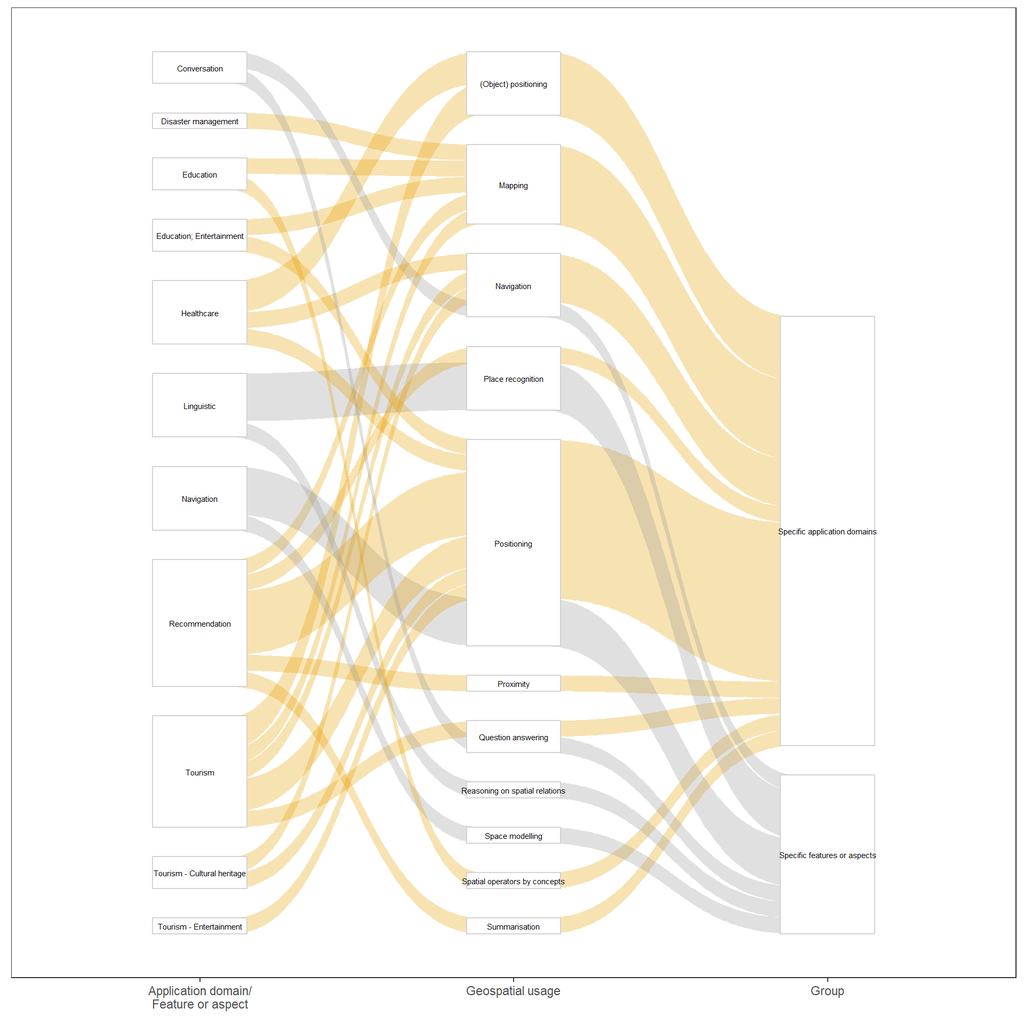

### Useful information/stats

Tables below show the numbers and percentages used in Section 3 of the paper. They are not shown as tables per se but as pieces of information intertwined in the narrative.

*Temporal distribution of virtual assistants according to their development status (`av_status`)*

| Development stage of virtual assisstants | N | % |
| --- | --- | --- |
| Design | 2 | 5% |
| Requirements and design | 4 | 11% |
| Implementation | 5 | 14% |
| Prototype | 26 | 70% |

*What AVs do they reach the status of operational implementation?*

AVs that reach operational implementation

| id | av_name |
| --- | --- |
| 001 | SpaceBook |
| 040 | Paval |
| 044 | NA |
| 049 | Loki |
| 053 | TreasureHuntBot |

*What are the most used platforms?*

Types of platforms

| av_platform | n |
| --- | --- |
| NA | 19 |
| Robot | 3 |
| Cortana | 2 |
| Telegram | 2 |
| Agent | 1 |
| Alexa | 1 |
| Ambro | 1 |
| Atrv-jr mobile robot | 1 |
| Google assistant | 1 |
| Kinect | 1 |
| Kiosk | 1 |
| Line | 1 |
| Microsoft hololens | 1 |
| Satnav | 1 |
| Teamtalk | 1 |

*How many virtual assisstants are named?*

Named virtual assisstants

| id | av_name | year | av_app_norm | av_application |
| --- | --- | --- | --- | --- |
| 001 | SpaceBook | 2018 | Tourism | Turismo |
| 011 | CitiCafe | 2018 | Recommendation | Citizen support for the solution of civic problems in the city |
| 015 | MIRob | 2018 | Healthcare | Assistance robot for the elderly and disabled |
| 016 | PeopleBot | 2019 | Healthcare | Assistance robot for the elderly and disabled |
| 035 | CAGA | 2013 | Education | Conversational interface for the use and access of geospatial functions |
| 040 | Paval | 2019 | Tourism | Pois recommendation |
| 045 | TITERIA | 2017 | Tourism; Cultural heritage | Smart tourist information points with travel information organized in ontologies |
| 047 | Trip 4 All | 2015 | Tourism | Tourism |
| 049 | Loki | 2019 | Recommendation | Chatbot with location recognition |
| 053 | TreasureHuntBot | 2018 | Education; Entertainment | Chatbot for multiplayer game |
| 056 | SatNav | 2019 | Navigation | Driver workload and environmental engagement associated with ‘active’ and ‘passive’ navigation systems. |
| 101 | Diana | 2019 | Disaster management | Disaster management (floods) |

Number of named virtual assisstants 32% (12/37)

### Figure 5. Temporal distribution of virtual assistants according to their technical approach (`av_arch`) and development status (`av_status`)

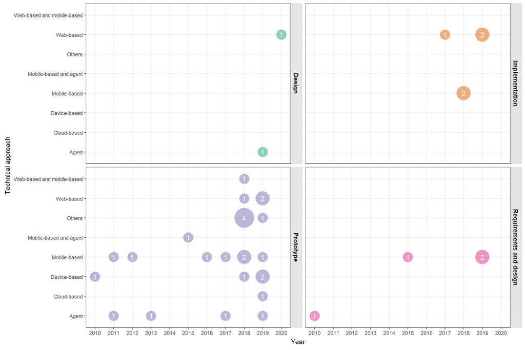

### Table 2. Summary of the virtual assisstants

| G | App domain | Geo goal | Ref - Year | App desc | Geo desc | Research areas |
| --- | --- | --- | --- | --- | --- | --- |
| 1 | Disaster management | Mapping | [101] 2019 | Disaster management (floods) | Georeferenced maps with layers of relevant information | Fuzzy search algorithms, Knowledge graphs |
| 1 | Education | Spatial operators by concepts | [035] 2013 | Conversational interface for the use and access of geospatial functions | Spatial data analysis | Conversational agent |
| 1 | Education | Mapping | [010] 2018 | Education (in communicative competencies) in construction environments | Space-time Immersion in a BIM environment | Bim environments, Conversational agent, Game engines |
| 1 | Healthcare | Positioning | [058] 2016 | Health | Monitoring of health parameters in patients through their location | Cloud, Iot |
| 1 | Healthcare | (Object) positioning | [015] 2018 | Assistance robot for the elderly and disabled | Identifying spatial relationships between objects within an environment | Assistive robotics, Human-robot interaction, Speech recognition, Uncertain term interpretation |
| 1 | Healthcare | Navigation | [027] 2018 | Outside navigation for blind pedestrians | Outdoor navigation | Conversational agent |
| 1 | Healthcare | (Object) positioning | [016] 2019 | Assistance robot for the elderly and disabled | Search for objects based on the recognition of their characteristics within an indoor environment | Assistive robotics, Human-robot interaction, Speech recognition, Uncertain term interpretation |
| 1 | Recommendation | Positioning | [037] 2010 | Customization of services depending on the position and user data (e.g., check-in at an airport) | Indoor positioning and navigation | Conversational agent, Multi-agent system |
| 1 | Recommendation | Positioning | [044] 2017 | Information consultation and recovery | Treatment of queries with location information of POIs (bussines) | Artificial intelligence |
| 1 | Recommendation | Mapping | [011] 2018 | Citizen support for the solution of civic problems in the city | Presentation of relevant information and registration of complaints in specific locations | Continuous learning, Conversational agent, Crowd sourcing, Intent classifier, Natural language processing, Proactive interaction |

[output cut: 27 more lines]

| G | App domain | Geo goal | Ref - Year | App desc | Geo desc | Research areas |
| --- | --- | --- | --- | --- | --- | --- |
| 1 | Disaster management | Mapping | [101] 2019 | Disaster management (floods) | Georeferenced maps with layers of relevant information | Fuzzy search algorithms, Knowledge graphs |
|  | Education | Spatial operators by concepts | [035] 2013 | Conversational interface for the use and access of geospatial functions | Spatial data analysis | Conversational agent |
|  |  | Mapping | [010] 2018 | Education (in communicative competencies) in construction environments | Space-time Immersion in a BIM environment | Bim environments, Conversational agent, Game engines |
|  | Healthcare | Positioning | [058] 2016 | Health | Monitoring of health parameters in patients through their location | Cloud, Iot |
|  |  | (Object) positioning | [015] 2018 | Assistance robot for the elderly and disabled | Identifying spatial relationships between objects within an environment | Assistive robotics, Human-robot interaction, Speech recognition, Uncertain term interpretation |
|  |  | Navigation | [027] 2018 | Outside navigation for blind pedestrians | Outdoor navigation | Conversational agent |
|  |  | (Object) positioning | [016] 2019 | Assistance robot for the elderly and disabled | Search for objects based on the recognition of their characteristics within an indoor environment | Assistive robotics, Human-robot interaction, Speech recognition, Uncertain term interpretation |
|  | Recommendation | Positioning | [037] 2010 | Customization of services depending on the position and user data (e.g., check-in at an airport) | Indoor positioning and navigation | Conversational agent, Multi-agent system |
|  |  | Positioning | [044] 2017 | Information consultation and recovery | Treatment of queries with location information of POIs (bussines) | Artificial intelligence |
|  |  | Mapping | [011] 2018 | Citizen support for the solution of civic problems in the city | Presentation of relevant information and registration of complaints in specific locations | Continuous learning, Conversational agent, Crowd sourcing, Intent classifier, Natural language processing, Proactive interaction |
|  |  | Positioning | [038] 2019 | Get local information from conversational agents embedded in a local neighborhood, complemented with navigation | Outdoor positioning | Conversational agent, Multi-agent system |
|  |  | Positioning | [007] 2019 | Restaurant recommendation | Outdoor positioning | Recommender systems, Similarity algorithms |
|  |  | Proximity | [008] 2019 | Information search system in digital libraries | Localization of digital resources in digital libraries through geospatial queries | Knowledge graphs, Linked open data, Natural language processing |
|  |  | Summarisation | [020] 2019 | Weather narration for blind people | Data access to meteorological data | Natural language processing |
|  |  | Place recognition | [049] 2019 | Chatbot with location recognition | Chat panel with a map viewer for access to geospatial information | Government open data, Knowledge graph, Linked data, Location-aware chatbots, Semantic enrichment |
|  | Tourism | Question answering | [018] 2012 | Tourism | Navigation based on questions-answers | Speech recognition, Text-to-speech responses |
|  |  | Mapping | [047] 2015 | Tourism | Multimedia and personalized experience about places visited | Gamification, Natural language processing |
|  |  | (Object) positioning | [024] 2018 | Guided tours | Identification of the object that the user looks at; 3D reconstruction of heritage buildings; data access | Semantic annotation, Speech recognition |
|  |  | Navigation | [001] 2018 | Turismo | Visibility of places of interest from the point of view of the tourist (pedestrian); route guide; outdoor navigation | Speech recognition, Text-to-speech responses |
|  |  | (Object) positioning | [021] 2019 | Guided tours | Identification of the object that the user looks at | Conversational agent, Mixed reality, Speech recognition |
|  |  | Positioning | [040] 2019 | Pois recommendation | Estimation of the need for information and possible geographical references expressed by users | Artificial intelligence, Knowledge graphs, Natural language processing, Ontologies, Semantic queries |
|  |  | Positioning | [012] 2019 | Outdoor navigation for touristic guides | Outdoor navigation, route planning and place guides | Artificial intelligence, Natural language processing |
|  | Tourism; Cultural heritage | Navigation | [057] 2011 | Tours in archeological sites | A tour to a set of exhibits located within a cultural heritage site by means of an avatar | Augmented reality, Automata, Rfid |
|  |  | Positioning | [045] 2017 | Smart tourist information points with travel information organized in ontologies | Regions of interest organize knowledge base, POI location | Affective computing, Animation engine, Embodied conversational agents, Ontologies, Speech recognition |
| 2 | Conversation | Navigation | [050] 2019 | Conversational interface between a human operator and a team of one or more robots | Detection and recovery of human-robot communication | Human–robot communication, Language grounding, Physically situated dialogue, Spoken-dialogue systems |
|  |  | Question answering | [041] 2020 | In situ conversational search and assistance system | Structural patterns of questions related to places and their human-generated responses using the MS MARCO V2.1 data set | Named entity recognition, Question answering |
|  | Education; Entertainment | Positioning | [054] 2015 | Gamified mobile guide applications | Efficiency improvement for gamification-based location | Embodied conversational agents, Gamification |
|  |  | Mapping | [053] 2018 | Chatbot for multiplayer game | Promote code-literacy through a multiplayer game | Code literacy, Messaging bot, Mixed reality |
|  | Linguistic | Place recognition | [048] 2017 | Automatic speech recognition for place entities | Recognition of words that define places in dialects and regions of interest organized in a knowledge base | Entity relation, Knowledge graphs, Speech recognition |
|  |  | Reasoning on spatial relations | [026] 2018 | Recognition of spatial relationships in text | Establishment of spatial relationships between objects in a scene | Machine learning, Natural language processing |
|  |  | Place recognition | [043] 2018 | Conversational system for indian languages | Identification and classification of words that denote places or location | Linear models, Named entity recognition, Neural network |
|  |  | Place recognition | [046] 2018 | Automatic text recognition for place entities | Recognition of places in unstructured text | Deep learning, Entity relation, Named entity recognition, Neural machine translation |
|  | Navigation | Space modelling | [025] 2010 | Evaluation of routes generated by a robot (indoor maps) | Indoor space modeling | Modeling of indoor spaces, Natural language description of indoor spaces |
|  |  | Positioning | [039] 2011 | Conversational learning agent | Navigation through complex and challenging space environments | Conversational agent |
|  |  | Positioning | [004] 2019 | Indoor navigation | Indoor positioning and navigation | Natural language processing |
|  |  | Positioning | [056] 2019 | Driver workload and environmental engagement associated with ‘active’ and ‘passive’ navigation systems. | Route selection | Natural language interfaces, Vehicle navigation systems |
|  | Tourism; Entertainment | Positioning | [014] 2018 | Education, tourism, entertainment | Physical location of objects and solving puzzles | Conversational agent, Deep-linking, Natural language processing |

### Figure 6. Most influential research areas found in the reviews papers

```
## label_key: av_areas
```

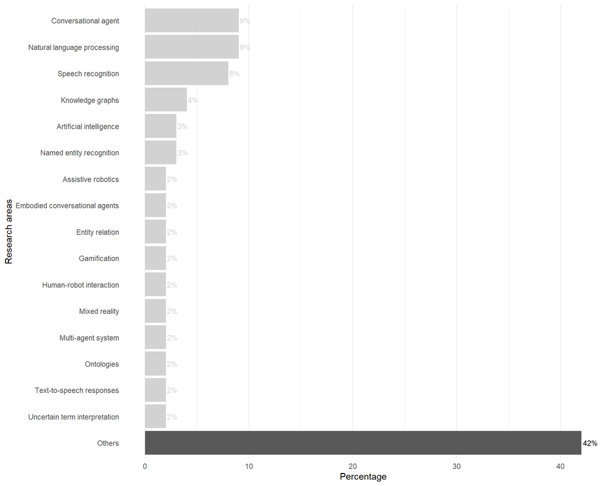

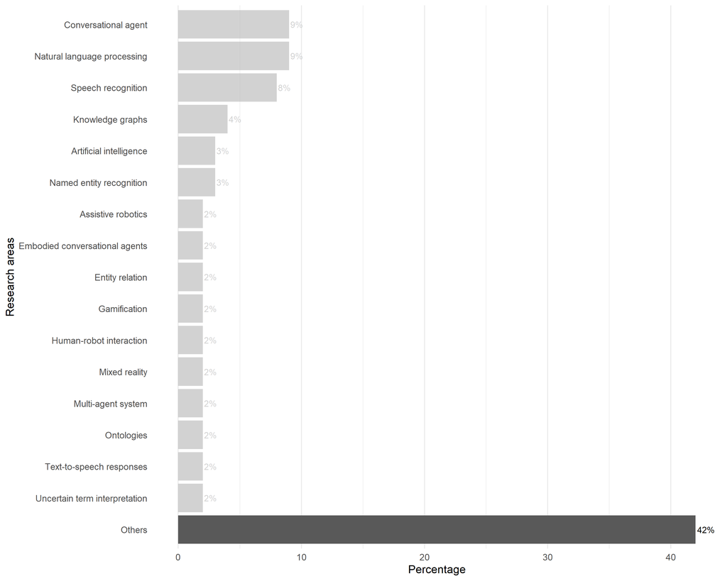

| Others: research areas cited once |
| --- |
| Affective computing |
| Animation engine |
| Augmented reality |
| Automata |
| Bim environments |
| Cloud |
| Code literacy |
| Continuous learning |
| Crowd sourcing |
| Deep-linking |
| Deep learning |
| Fuzzy search algorithms |
| Game engines |
| Government open data |
| Human–robot communication |
| Intent classifier |
| Iot |
| Knowledge graph |
| Language grounding |
| Linear models |
| Linked data |
| Linked open data |
| Location-aware chatbots |
| Machine learning |
| Messaging bot |
| Modeling of indoor spaces |
| Natural language description of indoor spaces |
| Natural language interfaces |
| Neural machine translation |
| Neural network |
| Physically situated dialogue |
| Proactive interaction |
| Question answering |
| Recommender systems |
| Rfid |
| Semantic annotation |
| Semantic enrichment |
| Semantic queries |
| Similarity algorithms |
| Spoken-dialogue systems |
| Vehicle navigation systems |